# PBMC_10k_v3_Seurat_R Notebook

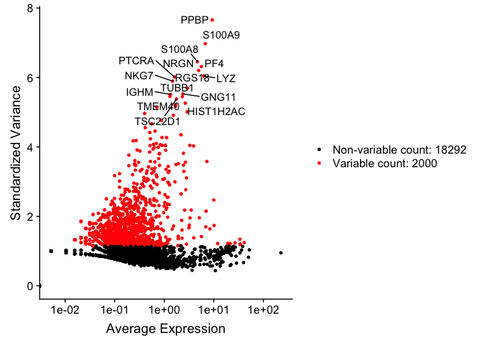

```r
top15 <- head(VariableFeatures(pbmc), 15)
plot3 <- VariableFeaturePlot(pbmc)
plot4 <- LabelPoints(plot = plot3, points = top15, repel = TRUE, xnudge = 0, ynudge = 0)
plot4
```

10. Linear Tansformation/Scaling across cells [(X-Mean)/Variance]: Done so that highly-expressed genes do not dominate in the analysis results. Standard Normal Distribution: Mean expression of each gene across cells = 0; Variance in expression of each gene across cells = 1.

```r
all.genes <- rownames(pbmc)
pbmc <- ScaleData(pbmc, features = all.genes) #Scaling all features
#pbmc <- ScaleData(pbmc) Scaling only the highly variable features
#pbmc[["RNA"]]@scale.data
```

11. Removing known unwanted variation: Focussing only on genomic DNA variation

```r
pbmc <- ScaleData(pbmc, vars.to.regress = "percent.mt")
```

12. Linear Dimensional Reduction: Principal Component Analysis (PCA).
    1. Supervised Method for determining relevant sources of heterogeneity.
    2. Each PC essentially representing a metafeature that combines information across a correlated feature set.
    3. The top principal components therefore represent a robust compression of the dataset.

```r
pbmc <- RunPCA(pbmc, features = VariableFeatures(object = pbmc))
```

```
## PC_ 1
## Positive:  RPS14, RPLP1, RPL13, RPS12, RPS6, RPS18, RPS29, RPS27, LTB, NEAT1
##     CD37, S100A4, S100A6, CD3D, TRBC2, IL32, TRAC, FOS, ARL4C, SELL
##     CALR, IL7R, IRF1, SYNE2, DUSP1, HSP90B1, ATP5IF1, GABPB1-AS1, SLFN5, CD7
## Negative:  TUBB1, PPBP, GP9, TMEM40, GNG11, CAVIN2, ACRBP, PF4, TSC22D1, PTCRA
##     NRGN, CMTM5, RGS18, MPP1, HIST1H2AC, PRKAR2B, CTTN, LMNA, MTURN, MMD
##     SPARC, PDLIM1, MAP3K7CL, C2orf88, TSPAN33, RAB32, TREML1, ESAM, CLDN5, PGRMC1
## PC_ 2
## Positive:  CD3D, IL32, TRAC, LTB, IL7R, TRBC2, SYNE2, SLFN5, NOSIP, ARL4C
##     RORA, TRBC1, LAT, TRABD2A, RPS29, AC058791.1, CD7, ITM2A, AQP3, GABPB1-AS1
##     CCR7, LEF1, PBXIP1, MAL, RPS27, PIM2, CAMK4, ATP6V0E2, INTS6, ODF2L
## Negative:  FCN1, MNDA, CSTA, TYROBP, S100A8, LYZ, CSF3R, AC020656.1, CLEC7A, CTSS
##     S100A12, PSAP, FGL2, S100A9, CST3, GRN, MS4A6A, AIF1, FPR1, VCAN
##     CYBB, CD14, TGFBI, TYMP, CD300E, CEBPD, RHOB, NCF2, FCER1G, FAM198B
## PC_ 3
## Positive:  MS4A1, IGHM, CD79A, IGHD, LINC00926, SNX22, CD22, HLA-DQA1, BANK1, RALGPS2
##     TNFRSF13C, SPIB, FAM129C, TCL1A, CD19, SWAP70, BCL11A, BLK, HVCN1, IGKC
##     CD79B, PLPP5, HLA-DMB, FCRL1, HLA-DRB5, AFF3, HLA-DRB1, HLA-DQB1, PCDH9, HLA-DQA2
## Negative:  ANXA1, IL32, S100A4, FYB1, TRAC, RORA, LGALS1, AAK1, CD3D, S100A9
##     ID2, GZMM, NEAT1, KLRD1, S100A6, SRGN, CD7, NKG7, SYNE2, PRF1
##     KLRF1, TYROBP, CTSW, ARL4C, FOS, GZMA, FCER1G, CTSD, FGFBP2, S1PR5
## PC_ 4
## Positive:  LTB, IL7R, MAL, TRABD2A, CD3D, SELL, CCR7, SERINC5, FYB1, CAMK4
##     TRAC, TSHZ2, LEF1, SLC2A3, AQP3, PBXIP1, FHIT, PASK, RGCC, SH3YL1
##     USP10, FTH1, LINC00513, RGS10, VCAN, LPIN2, BEX3, MNDA, NELL2, ARMH1
## Negative:  GNLY, KLRF1, GZMB, PRF1, NKG7, MYOM2, KLRD1, S1PR5, CTSW, HOPX
##     GZMA, SPON2, FGFBP2, NMUR1, SH2D1B, TRDC, CLIC3, CCL4, IGFBP7, EOMES
##     CST7, GZMH, CD300A, CX3CR1, TBX21, PTGDR, C1orf21, FCGR3A, NCR1, KIR2DL3
## PC_ 5
## Positive:  MYL9, MGAT4B, CCL5, CLU, GAS2L1, ITGB5, TREML1, UBE2E3, TMEM158, ITGA2B
##     PF4, PARVB, CAVIN2, NRGN, MARCH2, PTGS1, SPARC, HIST1H2AC, ACRBP, PPBP
##     GNG11, PADI4, MAP3K7CL, PGRMC1, BEX3, IRX3, PLEK, CMTM5, ZCCHC17, YWHAH
## Negative:  DNAH12, SLC35D3, FNBP1L, PCP2, MYCT1, AL365361.1, ADAM9, FRMD4B, STON2, PTK2
##     FAM214B, DENND2C, RNF122, FKBP1B, MBTD1, PANX1, LRRC8B, SPSB1, FGF2, KDM7A
##     MID1IP1, AC023157.3, FYB1, MCTP1, SLC2A3, RDX, ING2, TOP1, F2R, AC012615.1
```

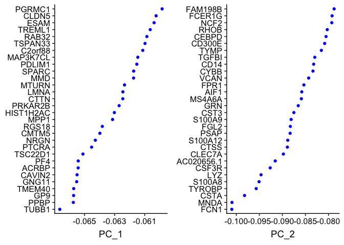

```r
#print(pbmc[["pca"]], dims = 1:5, nfeatures = 5) #Top 5
VizDimLoadings(pbmc, dims = 1:2, reduction = "pca") #Visualize top genes associated with reduction components
```

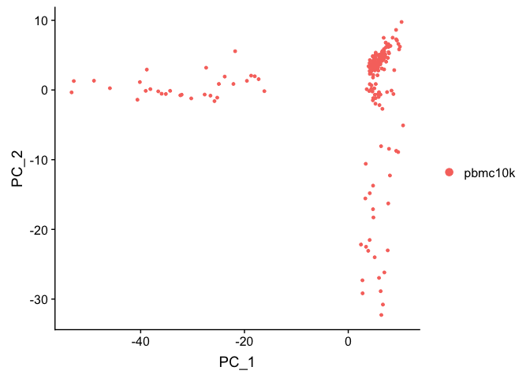

```r
DimPlot(pbmc, reduction = "pca") #Orthogonal Variation
```

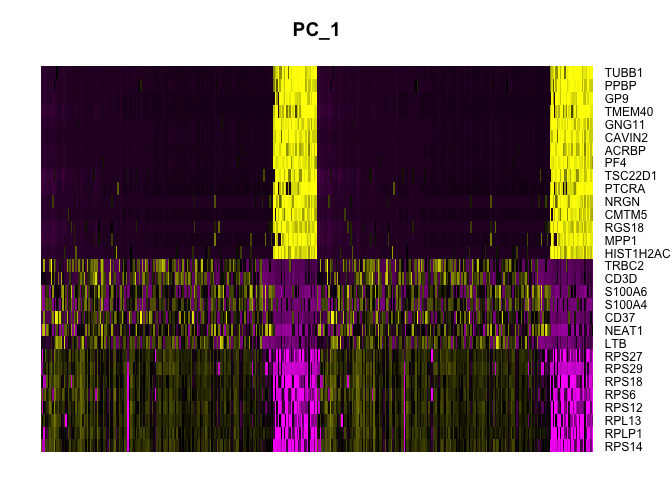

```r
DimHeatmap(pbmc, dims = 1, cells = 500, balanced = TRUE)
```

```r
#Visualization of heterogeneity.
#Cells and genes are sorted by their principal component scores
#Can see Smaller sub populations with strong separation
#Negatuve and Positive Markers
#DimHeatmap(pbmc, dims = 1:2, cells = 500, balanced = TRUE)
```

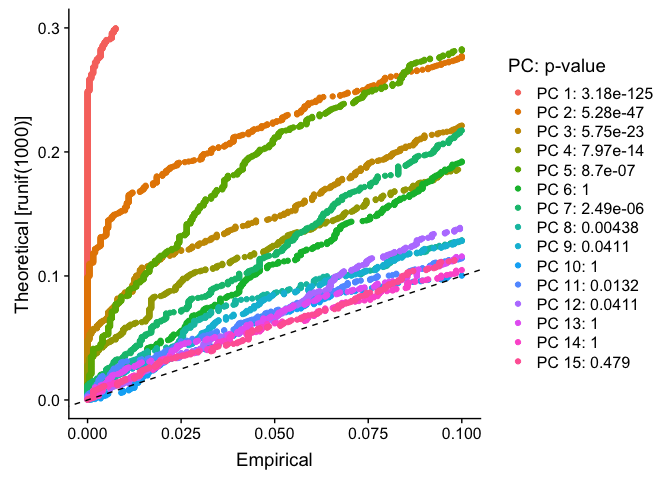

```r
pbmc <- JackStraw(pbmc, num.replicate = 100)
pbmc <- ScoreJackStraw(pbmc, dims = 1:20)
JackStrawPlot(pbmc, dims = 1:15)
```

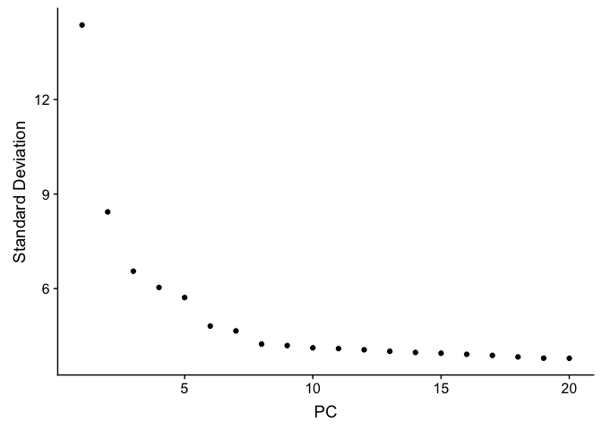

```r
ElbowPlot(pbmc)
```

14. Clustering of Cells: K-nearest neighbor (KNN) graph approach to find neighbours, i.e, cells with similar expression patterns. Expect Grouping/Clustering of similar cells.

```r
pbmc <- FindNeighbors(pbmc, dims = 1:10, reduction = "pca") #Dimensions of reduction to use as input
pbmc <- FindClusters(pbmc, resolution = 2.4)
```

```
## Modularity Optimizer version 1.3.0 by Ludo Waltman and Nees Jan van Eck
##
## Number of nodes: 191
## Number of edges: 5123
##
## Running Louvain algorithm...
## Maximum modularity in 10 random starts: 0.3438
## Number of communities: 9
## Elapsed time: 0 seconds
```

```r
#Higher resolution, more communities found. Howvever, overlaps also increase.
head(Idents(pbmc), 10) #Idents() used to find cluster IDs of the first five cells
```

```
## AAACCCAAGCGCCCAT AAAGAACTCTCATAGG AAAGGTAGTCTACACA AAATGGATCATTGCGA
##                1                0                8                0
## AACCATGGTATGGAAT AACCTTTCACTCCTGT AACGAAACACCCTAAA AAGATAGCAAACGAGC
##                8                7                3                0
## AAGTACCCAGGCCCTA AAGTACCGTGCTAGCC
##                7                0
## Levels: 0 1 2 3 4 5 6 7 8
```

15. Non-Linear Dimensional Reduction (tSNE/UMAP): To place similar cells together in low-dimensional space

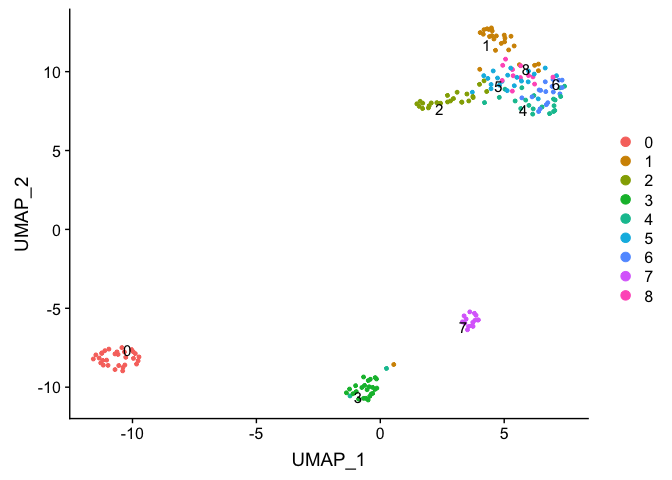

```r
library(reticulate)
library(umap)
pbmc <- RunUMAP(object = pbmc, dims = 1:10)
DimPlot(pbmc, reduction = "umap", label = TRUE, repel = TRUE, xnudge = 0, ynudge = 0) #Same as UMAPPlot()
```

16. Finding differentially expressed features/Cluster Biomarkers:
    1. min.pct argument requires a feature to be detected at a minimum percentage in either of the two groups of cells
    2. logfc.threshold argument requires a feature to be differentially expressed (on average) by some amount between the two groups

```r
library(magrittr)
#Identifies positive and negative markers of a single cluster (ident.1), compared to all other cells
cluster1.markers <- FindMarkers(pbmc, ident.1 = 1, min.pct = 0.25)
head(cluster1.markers, n = 5)
```

```
##               p_val avg_logFC pct.1 pct.2    p_val_adj
## GBP2   1.508703e-12 0.9529751  0.80 0.175 3.061460e-08
## DUSP4  4.505219e-12 0.5975768  0.28 0.000 9.141991e-08
## IL32   3.568986e-11 1.5100984  0.96 0.470 7.242185e-07
## CDC25B 1.392675e-10 0.7157164  0.68 0.133 2.826016e-06
## MIAT   2.534340e-10 0.5900922  0.56 0.072 5.142682e-06
```

```r
#Identifies positive and negative markers of a single cluster compared to cells from other specified clusters
cluster5.markers <- FindMarkers(pbmc, ident.1 = 5, ident.2 = c(6, 8), min.pct = 0.25)
head(cluster5.markers, n = 5)
```

```
##               p_val  avg_logFC pct.1 pct.2 p_val_adj
## MT-CO3 0.0001328759 -0.3948694 0.952 1.000         1
## TMSB4X 0.0005350231  0.2829971 1.000 1.000         1
## COX8A  0.0009331907  0.7274471 0.762 0.379         1
## SLC9A9 0.0010004823  0.5176830 0.333 0.000         1
## EMP3   0.0012279196  0.5831173 0.905 0.621         1
```

```r
#Identifies positive markers for all clusters
pbmc.markers <- FindAllMarkers(pbmc, only.pos = TRUE, min.pct = 0.25, logfc.threshold = log(2))
pbmc.markers %>% group_by(cluster) %>% top_n(n = 2, wt = avg_logFC)
```

```
## # A tibble: 18 x 7
## # Groups:   cluster [9]
##       p_val avg_logFC pct.1 pct.2 p_val_adj cluster gene
##       <dbl>     <dbl> <dbl> <dbl>     <dbl> <fct>   <chr>
##  1 1.15e-40     5.17  1     0.012  2.32e-36 0       PF4
##  2 6.31e-38     5.57  1     0.031  1.28e-33 0       PPBP
##  3 3.57e-11     1.51  0.96  0.47   7.24e- 7 1       IL32
##  4 7.41e-10     1.24  0.96  0.476  1.50e- 5 1       TRAC
##  5 1.04e-17     3.30  0.667 0.06   2.12e-13 2       NKG7
##  6 6.64e-11     3.33  0.5   0.066  1.35e- 6 2       GNLY
##  7 1.77e-16     3.86  1     0.389  3.58e-12 3       S100A8
##  8 2.92e-14     3.69  0.958 0.527  5.92e-10 3       S100A9
##  9 8.02e- 5     0.762 0.565 0.226  1.00e+ 0 4       ALKBH7
## 10 5.10e- 3     0.881 0.435 0.208  1.00e+ 0 4       CHD1
## 11 5.85e-10     1.32  1     0.418  1.19e- 5 5       IL7R
## 12 1.91e- 5     0.827 0.905 0.494  3.88e- 1 5       TRBC2
## 13 5.96e-10     0.861 0.412 0.029  1.21e- 5 6       POLR1E
## 14 1.85e- 3     0.829 0.294 0.069  1.00e+ 0 6       NELL2
## 15 9.49e-35     2.76  1     0.023  1.93e-30 7       MS4A1
## 16 6.18e-27     3.58  1     0.062  1.25e-22 7       IGHM
## 17 5.77e- 6     0.822 0.75  0.207  1.17e- 1 8       TRADD
## 18 5.40e- 5     1.12  1     0.581  1.00e+ 0 8       LTB
```

17. Assigning cell identity to clusters: Based on available literature in this case

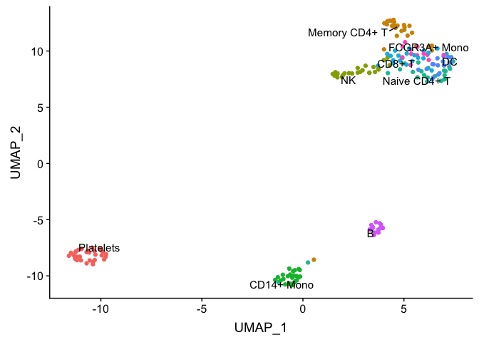

```r
new.cluster.ids <- c("Platelets","Memory CD4+ T","NK", "CD14+ Mono", "Naive CD4+ T", "CD8+ T", "DC", "B", "FCGR3A+ Mono")
names(new.cluster.ids) <- levels(pbmc)
pbmc <- RenameIdents(pbmc, new.cluster.ids)
DimPlot(pbmc, reduction = "umap", label = TRUE, pt.size = 1.5, repel = TRUE, xnudge = 0, ynudge = 0) + NoLegend()
```

18. Additional Visualizations for Marker Expression:

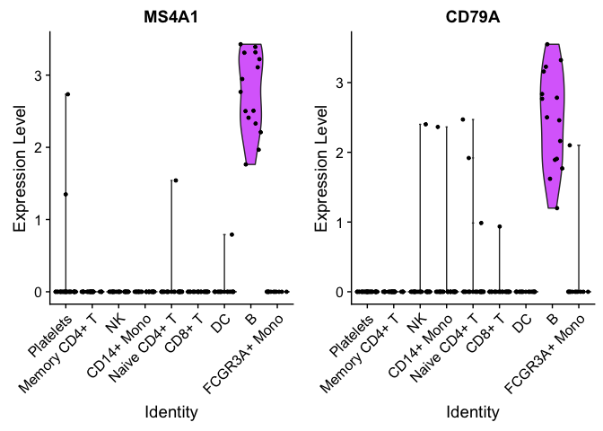

```r
#Violin Plots: Expression probability distributions across clusters
VlnPlot(pbmc, features = c("MS4A1", "CD79A"))
```

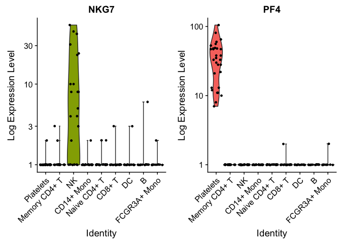

```r
#Violin Plots of raw counts
VlnPlot(pbmc, features = c("NKG7", "PF4"), slot = "counts", log = TRUE)
```

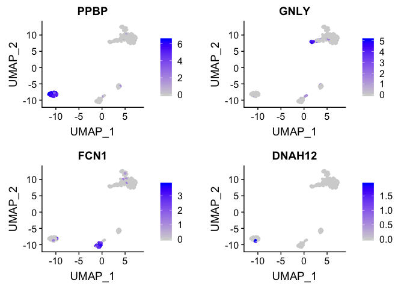

```r
#Visualizes feature expression on a tSNE or PCA plot
FeaturePlot(pbmc, features = c("PPBP", "GNLY", "FCN1", "DNAH12"))
```

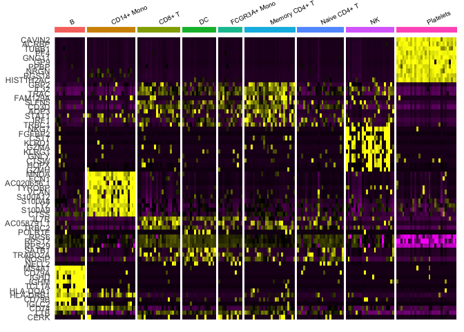

```r
#Expression heatmap for given cells and features for top 10 markers
top10 <- pbmc.markers %>% group_by(cluster) %>% top_n(n = 10, wt = avg_logFC)
DoHeatmap(pbmc, features = top10$gene,label = TRUE, size = 2.5, angle = 25) + NoLegend()
```